# Diseño factorial con bloques

## 1 Modelo factorial con un bloque

### 1.1 problema

El ingeniero diseña un experimento utilizando tres niveles del desorden de terreno y dos tipos de filtro. Los factores se consideran fijos. El experimento se realiza seleccionando al azar una combinación de los tratamientos (nivel de desorden y tipo de filtro), e introduciendo una señal que representa el objetivo en el campo del radar. La intensidad de esta señal se incrementa hasta que el operador la detecta. La variable de respuesta es el nivel de intensidad en el momento de la detección.

Dado que la disponibilidad de los operadores es limitada, se selecciona cuatro operadores al azar como bloques. Una vez elegido un operador, el orden de los tratamientos se determina aleatoriamente para evitar sesgos.\

| Desorden de terreno | Operador 1 Filtro 1 | Operador 1 Filtro 2 | Operador 2 Filtro 1 | Operador 2 Filtro 2 | Operador 3 Filtro 1 | Operador 3 Filtro 2 | Operador 4 Filtro 1 | Operador 4 Filtro 2 |
| --- | --- | --- | --- | --- | --- | --- | --- | --- |
| Bajo | 90 | 86 | 96 | 84 | 100 | 92 | 92 | 81 |
| Intermedio | 102 | 87 | 106 | 90 | 105 | 97 | 96 | 80 |
| Alto | 114 | 93 | 112 | 91 | 108 | 95 | 98 | 83 |

```r
# Preparar datos para diseño factorial con bloque
datos <- data.frame(
  operador = rep(1:4, each = 6),
  filtro = rep(rep(1:2, each = 3), times = 4),
  desorden = rep(c("Bajo", "Intermedio", "Alto"), times = 8),
  respuesta = c(
    90, 102, 114, 86, 87, 93,     # Operador 1
    96, 106, 112, 84, 90, 91,     # Operador 2
    100, 105, 108, 92, 97, 95,    # Operador 3
    92, 96, 98, 81, 80, 83        # Operador 4
  )
)

# Convertir a factores
datos$operador <- factor(datos$operador)
datos$filtro <- factor(datos$filtro)
datos$desorden <- factor(datos$desorden)
```

### 1.2 Analisis exploratorio

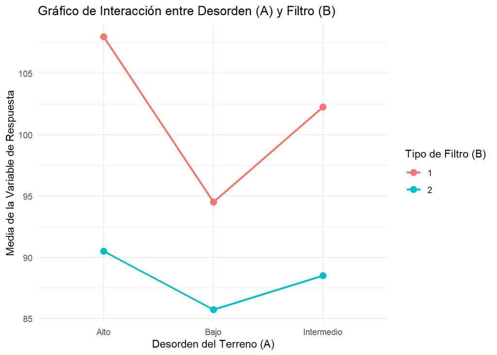

```r
# Cargar el paquete
library(ggplot2)

# Gráfico de interacción
ggplot(datos, aes(x = datos$desorden, y = datos$respuesta, color = datos$filtro, group = datos$filtro)) +
  stat_summary(fun = mean, geom = "point", size = 3) +         # puntos de media
  stat_summary(fun = mean, geom = "line", linewidth = 1) +     # líneas que conectan medias
  labs(
    title = "Gráfico de Interacción entre Desorden (A) y Filtro (B)",
    x = "Desorden del Terreno (A)",
    y = "Media de la Variable de Respuesta",
    color = "Tipo de Filtro (B)"
  ) +
  theme_minimal()
```

**Interpretación gráfico de interacción entre Desorden del Terreno (A) y Tipo de Filtro (B)**

El gráfico muestra la interacción entre el desorden del terreno (factor A con niveles: Alto, Bajo, Intermedio) y el tipo de filtro utilizado (factor B con niveles 1 y 2) sobre la media de la variable de respuesta.

Podemos observar lo siguiente:

- Para el **filtro tipo 1**, la media de la variable de respuesta es **más alta en terrenos con desorden alto** (~108), disminuye notablemente en terrenos con **desorden bajo** (~95) y vuelve a subir en el nivel intermedio (~102).
- Para el **filtro tipo 2**, la media se mantiene más constante, aunque también disminuye en terrenos con **desorden bajo** (~86), pero con menos variabilidad comparado al filtro tipo 1.

La diferencia en la pendiente de ambas líneas sugiere **una posible interacción entre los factores A y B**. Es decir, el efecto del tipo de filtro sobre la respuesta depende del nivel de desorden del terreno.

Esta interacción debe confirmarse estadísticamente mediante un análisis de varianza (ANOVA).

Para resolver este problema , se llevara a cabo un diseño factorial con un bloque, el modelo es el siguiente:

### 1.3 Modelo:

$$y_{ijk} = \mu + \tau_i + \beta_j + (\tau\beta)_{ij} + \delta_k +
\varepsilon_{ijk}
\quad
\left\{
\begin{array}{l}
i = 1, 2, 3\\
j = 1, 2 \\
k = 1, 2, 3, 4
\end{array}
\right.$$

Donde:

- $y_{ijk}$: es la observación del nivel de intensidad obtenida con el $i$-ésimo nivel de desorden de terreno, el $j$-ésimo tipo de filtro, y el $k$-ésimo operador.
- $\mu$: es la media general del nivel de intensidad.
- $\tau_i$: es el efecto del $i$-ésimo nivel de desorden de terreno (donde $i = 1$ para Bajo, $i = 2$ para Intermedio, $i = 3$ para Alto).
- $\beta_j$: es el efecto del $j$-ésimo tipo de filtro (donde $j = 1$ para Filtro 1, $j = 2$ para Filtro 2).
- $(\tau\beta)_{ij}$: es la interacción entre el $i$-ésimo nivel de desorden de terreno y el $j$-ésimo tipo de filtro.
- $\delta_k$: es el efecto del $k$-ésimo operador (donde $k = 1, 2, 3, 4$).
- $\varepsilon_{ijk}$: es el término de error aleatorio, asumido normalmente distribuido con media cero y varianza constante $\text{NID}(0, \sigma^2)$.

```r
# Ajustar modelo factorial con bloque y dos factores + interacción
modelo_factorialb1 <- aov(respuesta ~ desorden * filtro+operador , data = datos)
```

### 1.4 Comprobacion de supuestos

1. Normalidad de los residuos Hipótesis:
- $H_0$: Los residuos se distribuyen normalmente.
- $H_1$: Los residuos no se distribuyen normalmente.

```r
shapiro.test(modelo_factorialb1$residuals)
```

```
##
##  Shapiro-Wilk normality test
##
## data:  modelo_factorialb1$residuals
## W = 0.98247, p-value = 0.9366
```

**Interpretación**

La prueba de Shapiro-Wilk no entrega evidencia suficiente para rechazar la hipótesis nula de normalidad. Por lo tanto, se asume que los residuos del modelo siguen una distribución aproximadamente normal, cumpliendo con uno de los supuestos fundamentales del ANOVA.

2. Homogeneidad de varianzas (Homoscedasticidad) Hipótesis:

$H_0$: Las varianzas de los residuos son iguales entre los grupos.

$H_1$: Al menos un grupo tiene varianza diferente.

```r
bartlett.test(respuesta ~ interaction(desorden, filtro), data = datos)
```

```
##
##  Bartlett test of homogeneity of variances
##
## data:  respuesta by interaction(desorden, filtro)
## Bartlett's K-squared = 1.3437, df = 5, p-value = 0.9304
```

**Interpretación**

- **Efecto del Desorden del Terreno (Factor A):**

$$\begin{aligned}
H_0 &: \tau_1 = \tau_2 = \tau_3 = 0 \quad \text{(no hay efecto del
desorden)} \\
H_1 &: \text{Al menos un } \tau_i \neq 0 \quad \text{(existe efecto
del desorden)}
\end{aligned}$$

- **Efecto del Tipo de Filtro (Factor B):**

$$\begin{aligned}
H_0 &: \beta_1 = \beta_2 = 0 \quad \text{(no hay efecto del tipo de
filtro)} \\
H_1 &: \text{Al menos un } \beta_j \neq 0 \quad \text{(existe efecto
del tipo de filtro)}
\end{aligned}$$

- **Interacción entre Desorden del Terreno y Tipo de Filtro (A × B):**

$$\begin{aligned}
H_0 &: (\tau\beta)_{ij} = 0 \quad \text{para todo } i, j \\
H_1 &: \text{Al menos un } (\tau\beta)_{ij} \neq 0
\end{aligned}$$

- **Efecto del Operador (Bloque):**

$$\begin{aligned}
H_0 &: \delta_1 = \delta_2 = \delta_3 = \delta_4 = 0 \quad \text{(no
hay efecto del operador)} \\
H_1 &: \text{Al menos un } \delta_k \neq 0 \quad \text{(existe
efecto del operador)}
\end{aligned}$$

### 1.5 Tabla Annova:

```r
summary(modelo_factorialb1)
```

```
##                 Df Sum Sq Mean Sq F value   Pr(>F)
## desorden         2  335.6   167.8  15.132 0.000253 ***
## filtro           1 1066.7  1066.7  96.192 6.45e-08 ***
## operador         3  402.2   134.1  12.089 0.000277 ***
## desorden:filtro  2   77.1    38.5   3.476 0.057507 .
## Residuals       15  166.3    11.1
## ---
## Signif. codes:  0 '***' 0.001 '**' 0.01 '*' 0.05 '.' 0.1 ' ' 1
```

**interpretación**: No se rechaza la hipótesis nula (es decir, si el valor-p correspondiente a la interacción es mayor que el nivel de significancia establecido, $\alpha = 0.05$), por lo tanto, se concluye que no existe interacción significativa entre los factores.

En este caso, sí es válido interpretar los efectos principales por separado, ya que el efecto de un factor no depende del nivel del otro.

Dado que el valor-p asociado a la interacción es mayor que 0{,}05, se ajustará nuevamente el modelo ANOVA excluyendo el término de interacción, y se presentará la nueva tabla a continuación.

### 1.6 Nueva tabla annova sin interaccion :

```r
# Ajustar modelo factorial con bloque y los factores desorden y filtro
modelo_factorialb1b <- aov(respuesta ~ desorden + filtro+operador , data = datos)
summary(modelo_factorialb1b)
```

```
##             Df Sum Sq Mean Sq F value   Pr(>F)
## desorden     2  335.6   167.8  11.718 0.000633 ***
## filtro       1 1066.7  1066.7  74.495 1.28e-07 ***
## operador     3  402.2   134.1   9.362 0.000701 ***
## Residuals   17  243.4    14.3
## ---
## Signif. codes:  0 '***' 0.001 '**' 0.01 '*' 0.05 '.' 0.1 ' ' 1
```

**Interpretación**:

Por lo tanto al no haber interacción , y ambos factores de interes (desorden del terreno y filtro), rechazan $H_0$ en favor de que existen diferencias en los tratamientos de cada uno de los factores pero por separado , Realizaremos comparaciones multiples para saber que factor es el que es distinto al resto.

### 1.7 Comparación de Duncan

**Comparacion para el factor “desorden del terreno”

```r
# Comparación múltiple para el factor desorden del terreno
library(agricolae)
duncan_F1 <- duncan.test(modelo_factorialb1b, "desorden", group = FALSE)
print(duncan_F1$comparison)
```

```
##                   difference pvalue signif.       LCL       UCL
## Alto - Bajo            9.125 0.0002     ***  4.937851 13.312149
## Alto - Intermedio      3.875 0.0563       . -0.116767  7.866767
## Bajo - Intermedio     -5.250 0.0130       * -9.241767 -1.258233
```

**Interpretación**

- En la comparación entre desorden Alto y Bajo, se observa una diferencia significativa en la media de la variable respuesta. El nivel Alto es mayor que el nivel Bajo en 9.125 unidades, con un valor-p de 0.0002. Esto indica que el desorden Alto tiene un efecto considerablemente mayor que el desorden Bajo.
- Al comparar Alto con Intermedio, la diferencia de medias es 3.875, con un valor-p de 0.0563, lo que indica una diferencia marginalmente significativa. Aunque el nivel Alto tiende a ser mayor que el Intermedio, no hay suficiente evidencia estadística para confirmarlo con seguridad al 5%.
- En la comparación entre Bajo e Intermedio, la media del nivel Intermedio es 5.25 unidades mayor que la del nivel Bajo, con un valor-p de 0.0130. Esta diferencia es significativa, lo que indica que el desorden Intermedio también produce un efecto mayor que el desorden Bajo.

### 1.8 Comparación de Duncan

**Comparacion para el factor “Filtro”

```r
# Comparación múltiple para el factor desorden del terreno
library(agricolae)
duncan_F2 <- duncan.test(modelo_factorialb1b, "filtro", group = FALSE)
print(duncan_F2$comparison)
```

```
##       difference pvalue signif.      LCL     UCL
## 1 - 2   13.33333      0     *** 10.07407 16.5926
```

**Interpretación**:La diferencia entre las medias del tipo de filtro 1 y el tipo de filtro 2 es **estadísticamente significativa** con un valor p = 0 y un nivel de significancia del 0.05%. El intervalo de confianza al 95% para esta diferencia de medias va desde 10.07 hasta 16.59.

Esto indica que **el tipo de filtro tiene un efecto significativo sobreel nivel de intensidad**, y que el filtro tipo **1** genera una respuesta significativamente **mayor** que el filtro tipo **2**.

## 2 Modelo factorial con 2 bloques:

Durante el desarrollo del experimento relacionado con la detección de un objetivo mediante radar, el investigador se percató de ciertas limitaciones operativas que afectaban la planificación original. Inicialmente, el experimento consideraba dos factores: el **tipo de filtro** (con dos niveles) y el **desorden del terreno** (con tres niveles), bajo un diseño factorial $2 \times 3$.

Sin embargo, al momento de implementar el experimento, se detectaron dos restricciones importantes que motivaron una modificación en la estructura del diseño. En primer lugar, los **operadores** disponibles debían considerarse como bloques, ya que cada uno podía participar en una sola corrida por día. En segundo lugar, debido a limitaciones de tiempo y logística, sólo era posible realizar seis corridas por día, por lo que los **días** también debían tratarse como una segunda restricción sobre la aleatorización.

Ante esta situación, el investigador decidió utilizar un **cuadrado latino doble** de tamaño $6 \times 6$, que permitiera controlar simultáneamente las dos restricciones. Esto se justificaba, ya que el número de combinaciones del diseño factorial $2 \times 3 = 6$ coincidía exactamente con el número de niveles en cada una de las restricciones (seis operadores y seis días). De esta forma, cada combinación de tratamiento sería aplicada una sola vez por operador y una sola vez por día.

Las combinaciones de tratamientos se representaron mediante letras latinas, como sigue:

$$\begin{aligned}
A &= f_1 g_1, \quad B = f_1 g_2, \quad C = f_1 g_3, \\
D &= f_2 g_1, \quad E = f_2 g_2, \quad F = f_2 g_3.
\end{aligned}$$

Este diseño permitió al investigador llevar a cabo el experimento respetando las restricciones logísticas y de personal, asegurando al mismo tiempo una adecuada balanceabilidad en la aplicación de los tratamientos.

A continuación se presenta la tabla con los respectivos datos de información.

### 2.1 Tabla del experimento (Cuadrado Latino $6 \times 6$)

[output not shown]

```r
# Crear el data frame del Cuadrado Latino 6x6
datos <- data.frame(
  Dia = rep(1:6, each = 6),
  Operador = rep(1:6, times = 6),
  F = c("f1", "f1", "f1", "f2", "f2", "f2",
                  "f1", "f1", "f1", "f2", "f2", "f2",
                  "f1", "f2", "f2", "f1", "f2", "f1",
                  "f2", "f2", "f1", "f1", "f1", "f2",
                  "f2", "f1", "f2", "f2", "f1", "f1",
                  "f2", "f2", "f2", "f1", "f1", "f1"),
  G = c("g1", "g2", "g3", "g1", "g3", "g2",
        "g3", "g1", "g2", "g3", "g2", "g1",
        "g2", "g2", "g3", "g1", "g1", "g3",
        "g2", "g1", "g1", "g2", "g3", "g3",
        "g3", "g3", "g1", "g2", "g1", "g2",
        "g1", "g3", "g2", "g3", "g2", "g1"),
  Y = c(90, 106, 108, 81, 90, 88,
        114, 96, 105, 83, 86, 84,
        102, 90, 95, 92, 85, 104,
        87, 84, 100, 96, 110, 91,
        93, 112, 92, 80, 90, 98,
        86, 91, 97, 98, 100, 92)
)
# Convertir a factores
datos$F <- as.factor(datos$F)
datos$G <- as.factor(datos$G)
datos$Dia <- as.factor(datos$Dia)
datos$Operador <- as.factor(datos$Operador)
```

### 2.2 analisis exploratorio de los datos:

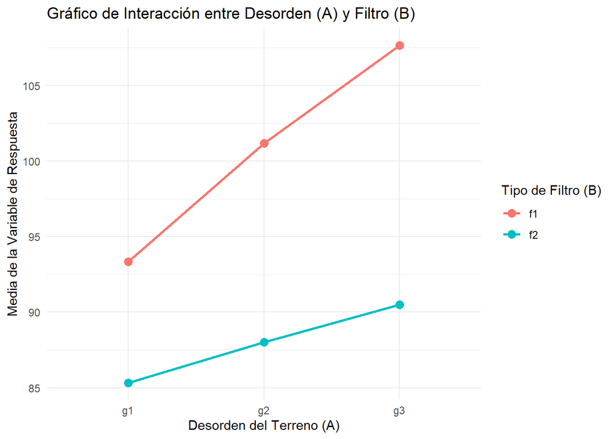

```r
# Cargar el paquete
library(ggplot2)

# Gráfico de interacción
ggplot(datos, aes(x = datos$G, y = datos$Y, color = datos$F, group = datos$F)) +
  stat_summary(fun = mean, geom = "point", size = 3) +         # puntos de media
  stat_summary(fun = mean, geom = "line", linewidth = 1) +     # líneas que conectan medias
  labs(
    title = "Gráfico de Interacción entre Desorden (A) y Filtro (B)",
    x = "Desorden del Terreno (A)",
    y = "Media de la Variable de Respuesta",
    color = "Tipo de Filtro (B)"
  ) +
  theme_minimal()
```

### 2.3 Interpretación del Gráfico de Interacción

El gráfico muestra la interacción entre el **desorden del terreno** (factor A) y el **filtro** (factor B) en la media de la variable de respuesta.

El eje horizontal representa los niveles de desorden del terreno:

- **g1**: desorden bajo
- **g2**: desorden intermedio
- **g3**: desorden alto

En el eje vertical se muestra la **media de la variable de respuesta**.

### 2.4 Observaciones:

- Ambas líneas muestran una **tendencia creciente** conforme aumenta el nivel de desorden del terreno, es decir, la media de la variable respuesta **aumenta** desde desorden bajo (*g1*) hasta desorden alto (*g3*).
- La **línea superior** (color rojo) presenta valores mucho más altos en la variable respuesta que la línea inferior (color azul), lo que indica que **un nivel del filtro está asociado a respuestas mayores en general**.
- Las líneas **no son paralelas**, sino que la distancia entre ellas **varía con el desorden**, lo que sugiere una **interacción entre los factores**: el efecto del desorden sobre la variable respuesta **depende del nivel del filtro**.
- En particular, el **efecto del aumento del desorden** es más pronunciado para el filtro asociado a la **línea roja** que para el filtro asociado a la **línea azul**.

### 2.5 Modelo del Experimento Factorial con Bloques Completos Aleatorizados

El modelo lineal para este experimento factorial con bloques completos aleatorizados es:

$$Y_{ijkl} = \mu + \tau_i + \beta_j + (\alpha\beta)_{ij} + \delta_k +
\gamma_l + \varepsilon_{ijkl}$$

Donde:

- $Y_{ijkl}$: es la observación del nivel de intensidad obtenida con el $i$-ésimo nivel de desorden de terreno, el $j$-ésimo tipo de filtro, el $k$-ésimo operador en el $l$-ésimo dia de trabajo.
- $\mu$: Media general.
- $\tau_i$: Efecto del $i$-ésimo nivel del tratamiento A (**Desorden del terreno**), con $i = 1, 2, \dots, a$.
- $\beta_j$: Efecto del $j$-ésimo nivel del tratamiento B (**Tipo de filtro**), con $j = 1, 2, \dots, b$.
- $(\tau\beta)_{ij}$: Efecto de la interacción entre los tratamientos A y B.
- $\delta_k$: Efecto del $k$-ésimo **operador** (bloque), con $k = 1, 2, 3, 4, 5, 6$.
- $\gamma_l$: Efecto del $l$-ésimo **día** (bloque), con $l = 1, 2, 3, 4, 5, 6$.
- $\varepsilon_{ijkl}$: Error aleatorio, con $\varepsilon_{ijkl} \sim \mathcal{N}(0, \sigma^2)$.

```r
modelob2<-aov(Y~F*G+Dia+Operador,data=datos)
```

### 2.6 Formulación de Hipótesis

Para el análisis del experimento con dos factores (tratamientos) y bloques, las hipótesis se formulan de la siguiente manera:

#### 2.6.1 Tratamiento A (Desorden del Terreno)

$$H_0^A : \tau_1 = \tau_2 = \tau_3 = 0 \quad \text{(No hay efecto del
desorden del terreno)} \\$$

$$H_1^A : \exists \, i \ne j \text{ tal que } \tau_i \ne \tau_j \quad
\text{(Existe al menos un efecto distinto)}$$

#### 2.6.2 Tratamiento B (Tipo de Filtro)

$$H_0^B : \beta_1 = \beta_2 = 0 \quad \text{(No hay efecto del tipo de
filtro)} \\$$

$$H_1^B : \exists \, i \ne j \text{ tal que } \beta_i \ne \beta_j \quad
\text{(Existe al menos un efecto distinto)}$$

#### 2.6.3 Interacción A × B

$$H_0^{AB} : (\tau\beta)_{ij} = 0 \quad \text{para todo } i, j \quad
\text{(No hay interacción entre A y B)} \\$$

$$H_1^{AB} : \exists \, (i,j) \text{ tal que } (\tau\beta)_{ij} \ne 0
\quad \text{(Existe interacción entre A y B)}$$

### 2.7 Comprobacion de supuestos

1. Normalidad de los residuos Hipótesis:
- $H_0$: Los residuos se distribuyen normalmente.
- $H_1$: Los residuos no se distribuyen normalmente.

```r
library(nortest)
lillie.test(modelob2$residuals)
```

```
##
##  Lilliefors (Kolmogorov-Smirnov) normality test
##
## data:  modelob2$residuals
## D = 0.07357, p-value = 0.8917
```

La prueba de Lilliefors no entrega evidencia suficiente para rechazar la hipótesis nula de normalidad. Por lo tanto, se concluye que los residuos del modelo pueden considerarse aproximadamente normales, lo cual respalda el cumplimiento del supuesto de normalidad en el análisis.

2. Homogeneidad de varianzas (Homoscedasticidad) Hipótesis:

$H_0$: Las varianzas de los residuos son iguales entre los grupos.

$H_1$: Al menos un grupo tiene varianza diferente.

```r
bartlett.test(Y ~ interaction(F, G), data = datos)
```

```
##
##  Bartlett test of homogeneity of variances
##
## data:  Y by interaction(F, G)
## Bartlett's K-squared = 1.9582, df = 5, p-value = 0.8549
```

**Interpretación**

La prueba de Bartlett no proporciona evidencia suficiente para rechazar la hipótesis nula de igualdad de varianzas. Por lo tanto, se asume que las varianzas entre los grupos son homogéneas, lo que respalda la validez del análisis de varianza (ANOVA) bajo este supuesto.

### 2.8 tabla annova con dos bloques

```r
summary(modelob2)
```

```
##             Df Sum Sq Mean Sq F value   Pr(>F)
## F            1 1469.4  1469.4 148.429 1.04e-10 ***
## G            2  571.5   285.7  28.864 1.27e-06 ***
## Dia          5    4.3     0.9   0.088 0.993365
## Operador     5  428.0    85.6   8.646 0.000171 ***
## F:G          2  126.7    63.4   6.400 0.007104 **
## Residuals   20  198.0     9.9
## ---
## Signif. codes:  0 '***' 0.001 '**' 0.01 '*' 0.05 '.' 0.1 ' ' 1
```

### 2.9 Interpretación de la Tabla ANOVA

A continuación se presenta la interpretación de los efectos analizados en el modelo:

### 2.10 Efecto del Filtro (F)

- Valor F = **148.43**, p-valor = **1.04e-10**
- El efecto del tipo de filtro es **altamente significativo**.
- Se concluye que **existen diferencias significativas** entre los tipos de filtro en cuanto a su efecto sobre la variable de respuesta.

### 2.11 Efecto del Desorden del Terreno (G)

- Valor F = **28.86**, p-valor = **1.27e-06**
- El desorden del terreno tiene un efecto **estadísticamente significativo**.
- Esto indica que los niveles de desorden influyen significativamente en la variable de respuesta.

### 2.12 Interacción entre Filtro y Desorden (F:G)

- Valor F = **6.40**, p-valor = **0.0071**
- Existe una **interacción significativa** entre el tipo de filtro y el nivel de desorden del terreno.
- Esto significa que el efecto del filtro **depende del nivel de desorden**, por lo que no deben analizarse de forma aislada.
- Se recomienda representar gráficamente esta interacción para facilitar su interpretación.

### 2.13 Comparación de Duncan

```r
 datos$tratamientos<-with(datos, interaction(F,G))
 # ajustar modelodeANOVAdeunavíasobrelainteracción

modelo_interaccion<-aov(Y~tratamientos+Dia+Operador,data=datos)

#aplicar pruebadeDuncansobrelainteracción

 duncan_tratamientos<-duncan.test(modelo_interaccion,trt="tratamientos",group=FALSE,alpha=0.05)

print(duncan_tratamientos$comparison)
```

```
##               difference pvalue signif.         LCL        UCL
## f1.g1 - f1.g2  -7.833333 0.0003     *** -11.6226739  -4.043993
## f1.g1 - f1.g3 -14.333333 0.0000     *** -18.3108678 -10.355799
## f1.g1 - f2.g1   8.000000 0.0005     ***   3.9028641  12.097136
## f1.g1 - f2.g2   5.333333 0.0107       *   1.3557988   9.310868
## f1.g1 - f2.g3   2.833333 0.1345          -0.9560073   6.622674
## f1.g2 - f1.g3  -6.500000 0.0019      ** -10.2893406  -2.710659
## f1.g2 - f2.g1  15.833333 0.0000     ***  11.6526625  20.014004
## f1.g2 - f2.g2  13.166667 0.0000     ***   9.0695308  17.263803
## f1.g2 - f2.g3  10.666667 0.0000     ***   6.6891322  14.644201
## f1.g3 - f2.g1  22.333333 0.0000     ***  18.0910670  26.575600
## f1.g3 - f2.g2  19.666667 0.0000     ***  15.4859959  23.847337
## f1.g3 - f2.g3  17.166667 0.0000     ***  13.0695308  21.263803
## f2.g1 - f2.g2  -2.666667 0.1577          -6.4560073   1.122674
## f2.g1 - f2.g3  -5.166667 0.0131       *  -9.1442012  -1.189132
## f2.g2 - f2.g3  -2.500000 0.1840          -6.2893406   1.289341
```

**Interpretación de Comparaciones Múltiples (Filtro × Desorden)**

### 2.15 2. Comparaciones entre filtros en el mismo nivel de desorden

- **f1.g1 vs f2.g1**: Diferencia positiva significativa (**8.00**), mayor respuesta con filtro 1.
- **f1.g2 vs f2.g2**: Diferencia significativa de **13.17 unidades**, favoreciendo al filtro 1.
- **f1.g3 vs f2.g3**: También significativa (**17.17**), con mayores respuestas en filtro 1.

**Conclusión:** Para todos los niveles de desorden, el **filtro 1 genera respuestas significativamente mayores** que el filtro 2.

### 2.16 3. Combinaciones con diferencias no significativas

- **f1.g1 vs f2.g3**, **f2.g1 vs f2.g2** y **f2.g2 vs f2.g3** presentan diferencias **no significativas**.
- Esto indica que en algunos casos (especialmente dentro del filtro 2), **los niveles de desorden no provocan cambios significativos** en la variable de respuesta.